# Spatial and Spatio-temporal Modelling

SHARP Bayesian Modeling for Environmental Health Workshop

Garyfallos Konstantinoudis

August 2023

# Part B: Ambient temperature and all-cause mortality in Italy

In this practical we will estimate the effect of temperature on all-cause mortality in Italy during 2013-2018. As the effect of temperature on health during summer months is expected to be elevated for warmer temperatures, we will fit a linear threshold model allowing for the effect to be different above and bellow the 80th percentile of the temperature. We selected the 80th percentile in line with the literature.

- First lets read the data

```r
data_italy <- readRDS(here("data", "Italy", "italy_mortality.rds"))
glimpse(data_italy)
```

```
## Rows: 96,300
## Columns: 13
## $ NOME_PROVINCIA          <chr> "Agrigento", "Agrigento", "Agrigento", "Agrige…
## $ SIGLA                   <chr> "AG", "AG", "AG", "AG", "AG", "AG", "AG", "AG"…
## $ date                    <date> 2013-05-04, 2013-05-05, 2013-05-06, 2013-05-0…
## $ deaths                  <dbl> 11, 11, 12, 8, 10, 9, 14, 14, 5, 12, 10, 11, 9…
## $ year                    <dbl> 2013, 2013, 2013, 2013, 2013, 2013, 2013, 2013…
## $ expected                <dbl> 11.75367, 11.75367, 11.75367, 11.75367, 11.753…
## $ hol                     <dbl> 0, 0, 0, 0, 0, 0, 0, 0, 0, 0, 0, 0, 0, 0, 0, 0…
## $ month                   <dbl> 5, 5, 5, 5, 5, 5, 5, 5, 5, 5, 5, 5, 5, 5, 5, 5…
## $ temperature_lag0_3      <dbl> 20.47926, 20.25625, 20.00277, 18.80698, 17.427…
## $ relativehumidity_lag0_3 <dbl> 41.23675, 49.12295, 54.27453, 56.57282, 63.886…
## $ o3_lag0_3               <dbl> 101.69444, 98.83333, 99.25000, 100.05556, 104.…
## $ pm10_lag0_3             <dbl> 40.13326, 39.26412, 35.22450, 29.67259, 26.707…
## $ week                    <dbl> 18, 18, 18, 19, 19, 19, 19, 19, 19, 19, 20, 20…
```

```r
summary(data_italy)
```

```
##  NOME_PROVINCIA        SIGLA                date                deaths
##  Length:96300       Length:96300       Min.   :2013-05-04   Min.   :  0.00
##  Class :character   Class :character   1st Qu.:2014-07-17   1st Qu.:  7.00
##  Mode  :character   Mode  :character   Median :2016-01-16   Median : 11.00
##                                        Mean   :2016-01-16   Mean   : 14.93
##                                        3rd Qu.:2017-07-17   3rd Qu.: 17.00
##                                        Max.   :2018-09-30   Max.   :272.00
##       year         expected            hol              month
##  Min.   :2013   Min.   :  2.909   Min.   :0.00000   Min.   :5.000
##  1st Qu.:2014   1st Qu.:  8.231   1st Qu.:0.00000   1st Qu.:6.000
##  Median :2016   Median : 11.674   Median :0.00000   Median :7.000
##  Mean   :2016   Mean   : 16.223   Mean   :0.01333   Mean   :7.033
##  3rd Qu.:2017   3rd Qu.: 18.153   3rd Qu.:0.00000   3rd Qu.:8.000
##  Max.   :2018   Max.   :118.261   Max.   :1.00000   Max.   :9.000
##  temperature_lag0_3 relativehumidity_lag0_3   o3_lag0_3       pm10_lag0_3
##  Min.   :-2.582     Min.   :24.01           Min.   :  1.00   Min.   : 2.917
##  1st Qu.:17.029     1st Qu.:63.92           1st Qu.: 96.06   1st Qu.:14.375
##  Median :20.380     Median :71.47           Median :108.38   Median :18.333
##  Mean   :19.996     Mean   :70.76           Mean   :111.35   Mean   :19.200
##  3rd Qu.:23.346     3rd Qu.:78.49           3rd Qu.:123.50   3rd Qu.:22.875
##  Max.   :32.962     Max.   :96.78           Max.   :257.50   Max.   :92.226
##       week
##  Min.   :18.0
##  1st Qu.:23.0
##  Median :29.0
##  Mean   :28.8
##  3rd Qu.:34.0
##  Max.   :40.0
```

```r
class(data_italy)
```

```
## [1] "tbl_df"     "tbl"        "data.frame"
```

- And the shapefile

```r
shp_italy <- read_sf(here("data", "Italy", "italy.geojson"))
glimpse(shp_italy)
```

```
## Rows: 107
## Columns: 7
## $ SIGLA      <chr> "VC", "NO", "TO", "AL", "AO", "IM", "CN", "AT", "CO", "SO",…
## $ mean.temp  <dbl> 17.425847, 19.928052, 15.250723, 20.214793, 9.235102, 18.04…
## $ mean.pop   <dbl> 3974.269, 8379.193, 51622.364, 9751.913, 2894.273, 4868.390…
## $ urbanicity <chr> "rural", "semi", "urban", "semi", "rural", "semi", "rural",…
## $ prop.gr    <dbl> 0.6571429, 0.5078534, 0.6626959, 0.7192547, 0.9014493, 0.85…
## $ SEP_q      <chr> "Q2", "Q3", "Q3", "Q1", "Q3", "Q4", "Q1", "Q1", "Q3", "Q1",…
## $ geometry   <MULTIPOLYGON [m]> MULTIPOLYGON (((438328.6 50..., MULTIPOLYGON (…
```

```r
summary(shp_italy)
```

```
##     SIGLA             mean.temp         mean.pop      urbanicity
##  Length:107         Min.   : 9.235   Min.   : 1958   Length:107
##  Class :character   1st Qu.:19.034   1st Qu.: 5605   Class :character
##  Mode  :character   Median :20.271   Median : 8861   Mode  :character
##                     Mean   :19.901   Mean   :12783
##                     3rd Qu.:21.646   3rd Qu.:13908
##                     Max.   :23.988   Max.   :95871
##     prop.gr          SEP_q                    geometry
##  Min.   :0.1993   Length:107         MULTIPOLYGON :107
##  1st Qu.:0.6256   Class :character   epsg:32632   :  0
##  Median :0.7335   Mode  :character   +proj=utm ...:  0
##  Mean   :0.6835
##  3rd Qu.:0.8008
##  Max.   :0.9014
```

```r
class(shp_italy)
```

```
## [1] "sf"         "tbl_df"     "tbl"        "data.frame"
```

## B1. A linear threshold model

$$\begin{equation}
\begin{aligned}
\hbox{O}_{itw} & \sim \hbox{Poisson}(E_{it} \lambda_{itw}) \\
\log \lambda_{itw} & = \beta_0 + \beta_1 X_{1itw} + \beta_2
X_{2itw} + \sum_{j=2}^5\beta_{3j} X_{3tw} + \\ &
\beta_{41}X_{4itw}I(X_{4itw} \leq c) + \beta_{42}X_{4itw}I(X_{4itw} >
c) + \\
& u_{tw} + \theta_{1i} + \phi_{1i}\\
u_{tw} & \sim \hbox{RW1}(0, \sigma^2_{u})\\
\theta_{1i} &\sim \hbox{Normal}(0, \sigma^2_{\theta_1})\\
{\bf \phi_1} & \sim \hbox{ICAR}({\bf W}, \sigma_{\phi_1}^2) \,\,
, \sum_i \phi_i = 0 \\
\beta_0 & \sim \text{Uniform}(-\infty, +\infty) \\
\beta_1, \beta_2, \beta_{3j}, \beta_{41}, \beta_{42} & \sim
\mathcal{N}(0, 1)
\end{aligned}
\end{equation}$$

where $X_{1itw}, X_{2itw}, X_{3tw}$ are the PM$_{10}$ concentration, relative humidity and day of the week, $\beta_1, \beta_2, \beta_{3j}$ the corresponding fixed effects. $\beta_{41}$ is the effect of temperatures $X_{4itw}$ lower than a threshold $c$, whereas, $\beta_{42}$ the effect of temperatures $X_{4itw}$ higher than $c$. Last $u_{tw}$ is a temporal random effect capturing seasonality, and $\theta_i + \phi_i$ the BYM model.

We will first write the model in NIMBLE.

```r
model_thr <- nimbleCode(
  {
    for(i in 1:N){

      O[i] ~ dpois(mu[i])
      mu[i] <- exp(log(expected[i]) + beta_0 +
                     beta_tmp[i]*temperature[i] +                              # effect of temperature
                     inprod(beta[1:K.b], X[i,1:K.b]) +                         # covariates
                     w[IDW[i]] +                                               # adjust for temporal trends
                     b_1[IDSP[i]])                                             # adjust for spatial trends

      Q[i] <- step(temperature[i] - x.change)
      beta_tmp[i] <- (1 - Q[i])*b_tmp_low + Q[i]*b_tmp_high
    }

    # Latent field
    for(j in 1:J){
      # For the unknown spatial confounding
      b_1[j] <- (1/sqrt(tau.b_1))*(sqrt((1-rho_1))*theta_1[j] +
                               sqrt(rho_1/scale)*phi_1[j])
      theta_1[j] ~ dnorm(0, sd = 1)
    }

    phi_1[1:J] ~ dcar_normal(adj = adj[1:L], weights = weights[1:L], num = num[1:J], tau = 1, zero_mean = 1)

    # The random walk for week
    w[1:Jw] ~ dcar_normal(adj = adjw[1:Lw], weights = weightsw[1:Lw], num = numw[1:Jw],
                        tau = tau.w, c = 2, zero_mean = 1)

    # set the priors of the fixed effects
    # intercept/covariates
    beta_0 ~ dnorm(0, sd = 1)
    # days of week
    for(kb in 1:K.b){
      beta[kb] ~ dnorm(0, sd = 1)
    }

    b_tmp_low ~ dnorm(0, sd = 1)
    b_tmp_low_unscaled <- b_tmp_low/x.sd   # scale back
    b_tmp_high ~ dnorm(0, sd = 1)
    b_tmp_high_unscaled <- b_tmp_high/x.sd # scale back

    # set the priors of the hyperparameters
    # The spatial field
    sd.b_1 ~ dgamma(shape = 1, rate = 2)
    tau.b_1 <- 1/(sd.b_1*sd.b_1)
    rho_1 ~ dbeta(1, 1)

    # The random walk
    sd.w ~ dgamma(shape = 1, rate = 4)
    tau.w <- 1/(sd.w*sd.w)

  }
)
```

- Define the data elements

```r
# data

data_italy$id_sp <- data_italy$SIGLA %>% as.factor() %>% as.numeric()
data_italy$id_week <- data_italy$week %>% as.factor() %>% as.numeric()
data_italy$id_year <- data_italy$year %>% as.factor() %>% as.numeric()

# set the max of the loop
N <- nrow(data_italy)

# confounders
data_italy$pm10_lag0_3 <- as.numeric(scale(data_italy$pm10_lag0_3))
data_italy$relativehumidity_lag0_3 <- as.numeric(scale(data_italy$relativehumidity_lag0_3))
# day of the week
data_italy$day <- wday(data_italy$date, label=TRUE, abbr=FALSE)
data_italy <- cbind(data_italy, dummy_cols(data_italy$day)[,-c(1:2)])

# Scale temperature
data_italy$temperature_lag0_3 <- as.numeric(scale(data_italy$temperature_lag0_3))
sd.temperature <- sd(data_italy$temperature_lag0_3, na.rm = TRUE)
mean.temperarture <- mean(data_italy$temperature_lag0_3, na.rm = TRUE)


X <- data_italy %>% select(
                    pm10_lag0_3, relativehumidity_lag0_3, hol,
                    .data_Monday, .data_Tuesday,
                    .data_Wednesday, .data_Thursday,
                    .data_Friday, .data_Saturday
)

K.b =  ncol(X)

NIMBLE_data <- list(

  O = data_italy$deaths,
  temperature = data_italy$temperature_lag0_3,
  X = X

)
```

- Prepare for constants

```r
# Define space and time structures:

# Space
J <- nrow(shp_italy)
shp_nb <- poly2nb(shp_italy)
nbWB_A <- nb2WB(nb = shp_nb)

# calculate scaling factor for bym2
W.scale <- nb2mat(shp_nb, zero.policy = TRUE, style = "B")
W.scale <- -W.scale
diag(W.scale) <- abs(apply(W.scale, 1, sum))
Q = inla.scale.model(W.scale, constr=list(A=matrix(1, nrow=1, ncol=nrow(W.scale)), e=0))
scale = exp((1/nrow(W.scale))*sum(log(1/diag(Q))))


# Time
# Function for random walks
weightsRW <- function(Q){

  rest.comp <- list()
  for(i in 3:(Q-2)){
      rest.comp[[i]] <- c(i-2, i-1, i+1, i+2)
  }

  rest.comp <- unlist(rest.comp)

  adj = c(2, 3, 1, 3, 4,
          rest.comp,
          c(Q-3, Q-2, Q, Q-2, Q-1)
          )

  num = c(2, 3, rep(4, times = c(Q-4)), 3, 2)

  weights = c(c(2, -1, 2, 4, -1),
              rep(c(-1, 4, 4, -1), times = c(Q-4)),
          c(-1, 4, 2, -1, 2))

  return(list(adj = adj, num = num, weights = weights))
}

# RW weeks
Jw <- max(data_italy$id_week)
W_weights <- weightsRW(Q = Jw)
```

- Define constants

```r
NIMBLE_constants <- list(
  # for loops
  N = N,
  J = J,
  Jw = Jw,
  K.b =  K.b,

  # IDs
  IDW = data_italy$id_week,
  IDSP = data_italy$id_sp,

  # space
  L = length(nbWB_A$weights),
  adj = nbWB_A$adj,
  num = nbWB_A$num,
  weights = nbWB_A$weights,

  # week
  Lw = length(W_weights$weights),
  adjw = W_weights$adj,
  numw = W_weights$num,
  weightsw = W_weights$weights,

  x.sd = sd.temperature,
  expected = data_italy$expected,
  scale = scale,

  x.change = quantile(data_italy$temperature_lag0_3, probs = 0.8)

)
```

- Set initial values (let’s run just one chain)

```r
initials =
  list(
    # fixed effects
    beta_0 = 0,
    beta = rep(0, K.b),
    b_tmp_low = 0,
    b_tmp_high = 0,
    # spatial field
    theta_1 = rep(0, times = J),
    phi_1 = rep(0, times = J),
    sd.b_1 = 1,
    rho_1 = 0.5,

    # random walks
    w = rep(0, times = Jw),
    sd.w = 1
)
```

- and the parameters to monitor

```r
  # parameters to monitor
  parameters = c("beta_0", "beta",
                 "b_tmp_low_unscaled", "b_tmp_high_unscaled",
                 "b_1",
                 "sd.b_1",
                 "rho_1",
                 "w", "tau.w")
```

- and run NIMBLE

```r
# NIMBLE call

# define the model
t_0 <- Sys.time()
nimble_model <- nimbleModel(
  code = model_thr,
  data = NIMBLE_data,
  constants = NIMBLE_constants,
  inits = initials,
  name = "model_thr",
  calculate = FALSE
)

# compile model
Cmodel <- compileNimble(nimble_model)
Cmodel$calculate()

nimble_model$origInits

# configure and build the MCMC
conf <- configureMCMC(nimble_model, monitors = parameters)
MCMC <- buildMCMC(conf)

# compile the MCMC
cMCMC <- compileNimble(MCMC, project = Cmodel)
t_1 <- Sys.time()
t_1 - t_0 # ~ 12 minutes



# MCMC setting

ni <- 50000   # nb iterations
nt <- 25      # thinning interval
nb <- 25000   # nb iterations as burn-in
nc <- 1       # nb chains


# run the MCMC
t_0 <- Sys.time()
mod_LT_res <- runMCMC(cMCMC, niter = ni, nburnin = nb, thin = nt, samples = TRUE, summary = FALSE)
t_1 <- Sys.time()
t_1 - t_0

saveRDS(mod_LT_res, file = "NIMBLE_LT_B1")
```

- Check convergence

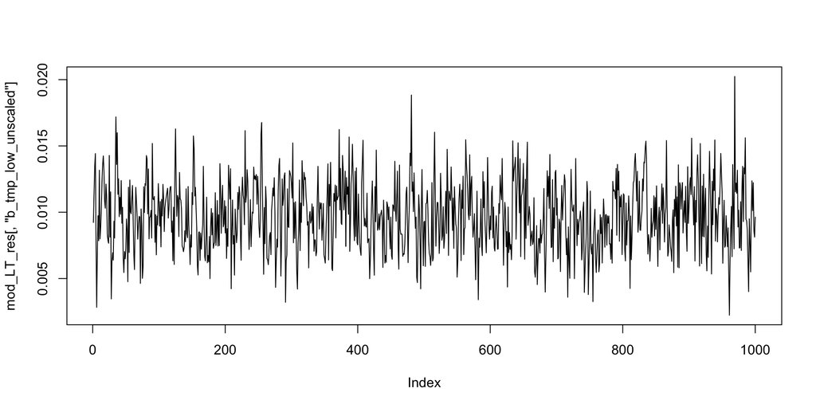

```r
plot(mod_LT_res[,"b_tmp_low_unscaled"], type = "l")
```

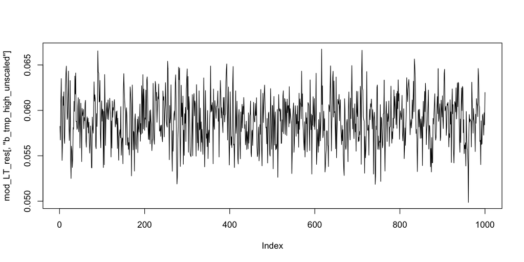

```r
plot(mod_LT_res[,"b_tmp_high_unscaled"], type = "l")
```

```r
plot(mod_LT_res[,"beta[1]"], type = "l")
plot(mod_LT_res[,"beta[2]"], type = "l")
plot(mod_LT_res[,"beta[3]"], type = "l")
plot(mod_LT_res[,"beta[4]"], type = "l")
plot(mod_LT_res[,"beta[5]"], type = "l")
plot(mod_LT_res[,"beta[6]"], type = "l")
plot(mod_LT_res[,"beta[7]"], type = "l")
plot(mod_LT_res[,"beta[8]"], type = "l")
plot(mod_LT_res[,"beta[9]"], type = "l")

plot(mod_LT_res[,"rho_1"], type = "l")
plot(mod_LT_res[,"sd.b_1"], type = "l")

plot(mod_LT_res[,"tau.w"], type = "l")

plot(mod_LT_res[,"b_1[1]"], type = "l")
plot(mod_LT_res[,"b_1[13]"], type = "l")
plot(mod_LT_res[,"b_1[90]"], type = "l")

plot(mod_LT_res[,"w[1]"], type = "l")
plot(mod_LT_res[,"w[10]"], type = "l")
plot(mod_LT_res[,"w[15]"], type = "l")
```

- Examine spatial and temporal correlation

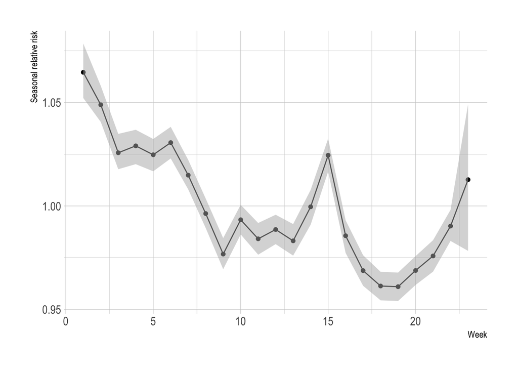

```r
# Temporal trends:
mod_LT_res %>%
  as_tibble() %>%
  dplyr::select(starts_with("w")) %>%
  apply(., 2, quantile, probs = c(0.5, 0.025, 0.975)) %>%
  t() %>%
  as.data.frame() %>%
  dplyr::mutate(id_week = rownames(.), id = gsub("\\D", "", id_week) %>% as.numeric()) %>%
  ggplot(data=.) +
  geom_point(aes(x=id, y=`50%` %>% exp())) +
  geom_line(aes(x=id, y=`50%` %>% exp())) +
  geom_ribbon(aes(x=id, ymin = `2.5%` %>% exp(), ymax = `97.5%` %>% exp()), alpha = 0.5, fill = "grey70") +
  xlab("Week") + ylab("Seasonal relative risk")
```

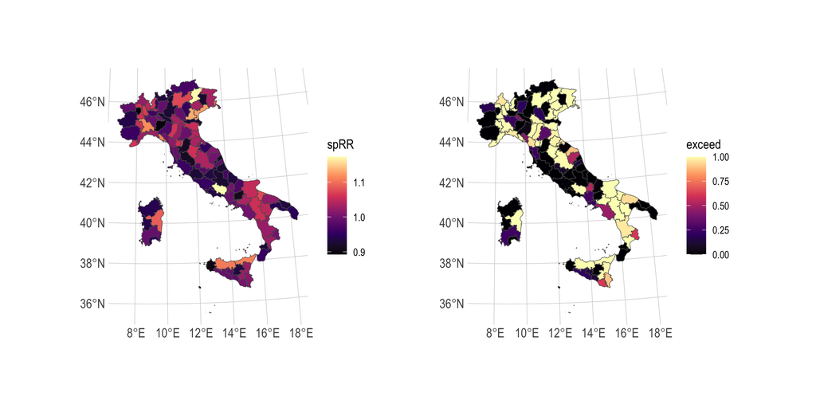

```r
# Spatial trends:
mod_LT_res %>%
  as_tibble() %>%
  dplyr::select(starts_with("b_1")) %>%
  apply(., 2, median) %>% exp() -> shp_italy$spRR

mod_LT_res %>%
  as_tibble() %>%
  dplyr::select(starts_with("b_1")) %>%
  apply(., 2, function(X) mean(X>0)) -> shp_italy$exceed


shp_italy %>%
  ggplot(data=.) +
  geom_sf(aes(fill = spRR)) +
  scale_fill_viridis_c(option = "A")|
  shp_italy %>%
  ggplot(data=.) +
  geom_sf(aes(fill = exceed)) +
  scale_fill_viridis_c(option = "A")
```

- Examine the effects of the confounders:

```r
mod_LT_res %>%
  as_tibble() %>%
  dplyr::select(starts_with("beta[")) %>%
   apply(., 2, quantile, probs = c(0.5, 0.025, 0.975)) %>% exp() %>%
  t() %>% as.data.frame() -> cov.eff

rownames(cov.eff) <- colnames(X)
cov.eff
```

```
##                               50%      2.5%     97.5%
## pm10_lag0_3             1.0226008 1.0202160 1.0251805
## relativehumidity_lag0_3 0.9865082 0.9845651 0.9884487
## hol                     0.9846048 0.9697399 0.9974270
## .data_Monday            1.0327038 1.0260139 1.0389933
## .data_Tuesday           1.0324950 1.0261921 1.0396916
## .data_Wednesday         1.0366226 1.0302337 1.0432884
## .data_Thursday          1.0325880 1.0260230 1.0388250
## .data_Friday            1.0284720 1.0219797 1.0352027
## .data_Saturday          1.0085176 1.0022935 1.0146301
```

- Examine the effects of the temperature:

```r
mod_LT_res %>%
  as_tibble() %>%
  dplyr::select(starts_with("b_tmp")) %>%
   apply(., 2, quantile, probs = c(0.5, 0.025, 0.975)) %>% exp() %>%
  t() %>% as.data.frame()
```

```
##                          50%     2.5%    97.5%
## b_tmp_high_unscaled 1.060706 1.055173 1.066323
## b_tmp_low_unscaled  1.009741 1.005028 1.015245
```

## B2. A model with spatially varying temperature

In the context of temperature and health, we expect spatial vulnerabilities on the effect of heat. This is due to known (green space, deprivation, air-pollution) or unknown spatial factors that interact with temperature. In this section, we will fit a model with spatially varying temperature coefficients, capturing the spatial vulnerabilities to heat exposure. The mathematical notation is very similar with B1:

$$\begin{equation}
\begin{aligned}
\hbox{O}_{itw} & \sim \hbox{Poisson}(E_{it} \lambda_{itw}) \\
\log \lambda_{itw} & = \beta_0 + \beta_1 X_{1itw} + \beta_2
X_{2itw} + \sum_{j=2}^5\beta_{3j} X_{3tw} + \\ &
\beta_{41}X_{4itw}I(X_{4itw} \leq c) + \beta_{42i}X_{4itw}I(X_{4itw}
> c) + \\
& u_{tw} + \theta_{1i} + \phi_{1i}\\
\beta_{42i} & = \beta_{420} + \theta_{2i} + \phi_{2i}
u_{tw} & \sim \hbox{RW1}(0, \sigma^2_{u})\\
\theta_{1i} &\sim \hbox{Normal}(0, \sigma^2_{\theta_1})\\
{\bf \phi_1} & \sim \hbox{ICAR}({\bf W}, \sigma_{\phi_1}^2) \,\,
, \sum_i \phi_i = 0 \\
\theta_{2i} &\sim \hbox{Normal}(0, \sigma^2_{\theta_{2}})\\
{\bf \phi_2} & \sim \hbox{ICAR}({\bf W}, \sigma_{\phi_{2}}^2) \,\,
, \sum_i \phi_i = 0 \\
\end{aligned}
\end{equation}$$

The only difference from the model in B1 is that here the effect of higher temperatures $\beta_{42i}$ has an $i$ index, i.e. is allowed to vary in space, based on a BYM prior.

```r
model_svc <- nimbleCode(
  {
    for(i in 1:N){

      O[i] ~ dpois(mu[i])
      mu[i] <- exp(log(expected[i]) + beta_0 +
                     beta_tmp[i]*temperature[i] +                              # effect of temperature
                     inprod(beta[1:K.b], X[i,1:K.b]) +                         # covariates
                     w[IDW[i]] +                                               # adjust for temporal trends
                     b_1[IDSP[i]])                                             # adjust for spatial trends

      Q[i] <- step(temperature[i] - x.change)
      beta_tmp[i] <- (1 - Q[i])*b_tmp_low + Q[i]*b_tmp_highSVC[IDSP[i]]
    }

    # Latent field
    for(j in 1:J){
      # For the unknown spatial confounding
      b_1[j] <- (1/sqrt(tau.b_1))*(sqrt((1-rho_1))*theta_1[j] +
                               sqrt(rho_1/scale)*phi_1[j])
      theta_1[j] ~ dnorm(0, sd = 1)

      # for the spatially varying coefficient
      b_tmp_highSVC[j] <- b_2[j]
      b_2[j] <- (1/sqrt(tau.b_2))*(sqrt((1-rho_2))*theta_2[j] +
                               sqrt(rho_2/scale)*phi_2[j])

      theta_2[j] ~ dnorm(b_tmp_high, sd = 1)
    }

    phi_1[1:J] ~ dcar_normal(adj = adj[1:L], weights = weights[1:L], num = num[1:J], tau = 1, zero_mean = 1)
    phi_2[1:J] ~ dcar_normal(adj = adj[1:L], weights = weights[1:L], num = num[1:J], tau = 1, zero_mean = 1)

    # The random walk for week
    w[1:Jw] ~ dcar_normal(adj = adjw[1:Lw], weights = weightsw[1:Lw], num = numw[1:Jw],
                        tau = tau.w, c = 2, zero_mean = 1)

    # set the priors of the fixed effects
    # intercept/covariates
    beta_0 ~ dnorm(0, sd = 1)
    # days of week
    for(kb in 1:K.b){
      beta[kb] ~ dnorm(0, sd = 1)
    }

    b_tmp_low ~ dnorm(0, sd = 1)
    b_tmp_low_unscaled <- b_tmp_low/x.sd   # scale back
    b_tmp_high ~ dnorm(0, sd = 1)
    b_tmp_high_unscaled <- b_tmp_high/x.sd # scale back

    # set the priors of the hyperparameters
    # The spatial field
    sd.b_1 ~ dgamma(shape = 1, rate = 2)
    tau.b_1 <- 1/(sd.b_1*sd.b_1)
    rho_1 ~ dbeta(1, 1)

    # the svc
    sd.b_2 ~ dgamma(shape = 1, rate = 2)
    tau.b_2 <- 1/(sd.b_2*sd.b_2)
    rho_2 ~ dbeta(1, 1)

    # The random walk
    sd.w ~ dgamma(shape = 1, rate = 4)
    tau.w <- 1/(sd.w*sd.w)

  }
)
```

- modify parameters and initials

```r
# Initials
c(initials,
  list(
  theta_2 = rep(0, times = J),
  phi_2 = rep(0, times = J),
  sd.b_2 = 1,
  rho_2 = 0.5)) -> initialssvc

# parameters to monitor
c(parameters, "b_2", "sd.b_2", "rho_2") -> parametersvsc
```

- and run NIMBLE

```r
# NIMBLE call

# define the model
t_0 <- Sys.time()
nimble_model <- nimbleModel(
  code = model_svc,
  data = NIMBLE_data,
  constants = NIMBLE_constants,
  inits = initialssvc,
  name = "model_svc",
  calculate = FALSE
)

nimble_model$initializeInfo()

# compile model
Cmodel <- compileNimble(nimble_model)
Cmodel$calculate()

nimble_model$origInits

# configure and build the MCMC
conf <- configureMCMC(nimble_model, monitors = parametersvsc)
MCMC <- buildMCMC(conf)

# compile the MCMC
cMCMC <- compileNimble(MCMC, project = Cmodel)
t_1 <- Sys.time()
t_1 - t_0 # ~ 12 minutes



# MCMC setting

ni <- 50000   # nb iterations
nt <- 25      # thinning interval
nb <- 25000   # nb iterations as burn-in
nc <- 1       # nb chains


# run the MCMC
t_0 <- Sys.time()
mod_svc_res <- runMCMC(cMCMC, niter = ni, nburnin = nb, thin = nt, samples = TRUE, summary = FALSE)
t_1 <- Sys.time()
t_1 - t_0

saveRDS(mod_svc_res, file = "NIMBLE_SVC_B2")
```

- Check convergence

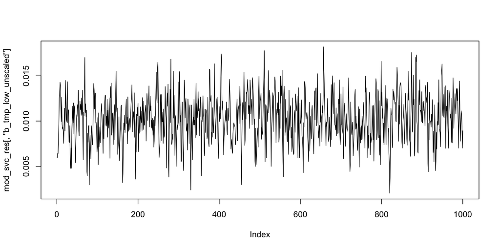

```r
plot(mod_svc_res[,"b_tmp_low_unscaled"], type = "l")
```

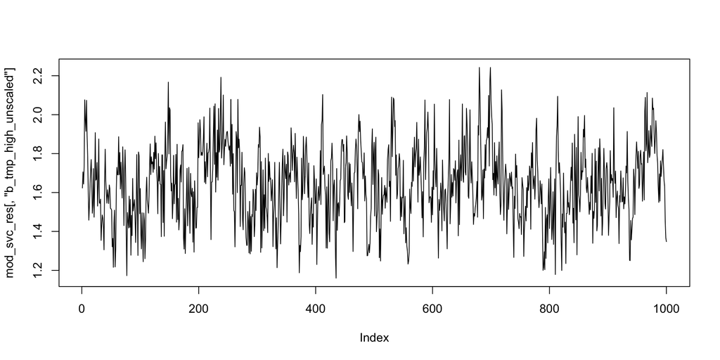

```r
plot(mod_svc_res[,"b_tmp_high_unscaled"], type = "l")
```

```r
plot(mod_svc_res[,"beta[1]"], type = "l")
plot(mod_svc_res[,"beta[2]"], type = "l")
plot(mod_svc_res[,"beta[3]"], type = "l")
plot(mod_svc_res[,"beta[4]"], type = "l")
plot(mod_svc_res[,"beta[5]"], type = "l")
plot(mod_svc_res[,"beta[6]"], type = "l")
plot(mod_svc_res[,"beta[7]"], type = "l")
plot(mod_svc_res[,"beta[8]"], type = "l")
plot(mod_svc_res[,"beta[9]"], type = "l")

plot(mod_svc_res[,"rho_1"], type = "l")
plot(mod_svc_res[,"sd.b_1"], type = "l")

plot(mod_svc_res[,"tau.w"], type = "l")

plot(mod_svc_res[,"b_1[1]"], type = "l")
plot(mod_svc_res[,"b_1[13]"], type = "l")
plot(mod_svc_res[,"b_1[90]"], type = "l")

plot(mod_svc_res[,"w[1]"], type = "l")
plot(mod_svc_res[,"w[10]"], type = "l")
plot(mod_svc_res[,"w[15]"], type = "l")

plot(mod_svc_res[,"b_2[1]"], type = "l")
plot(mod_svc_res[,"b_2[13]"], type = "l")
plot(mod_svc_res[,"b_2[90]"], type = "l")
```

- Examine the effects of the temperature:

```r
mod_svc_res %>%
  as_tibble() %>%
  dplyr::select(starts_with("b_2")) %>%
   apply(., 2, quantile, probs = c(0.5, 0.025, 0.975)) %>% exp() %>%
  t() %>% as.data.frame() -> restemp

mean(restemp$`50%`)
```

```
## [1] 1.07473
```

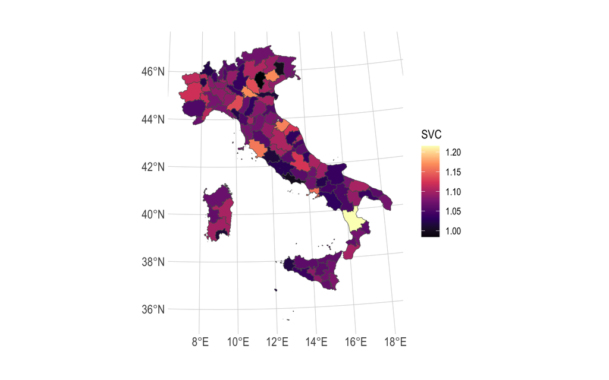

```r
shp_italy$SVC <- restemp$`50%`

ggplot(data=shp_italy) +
  geom_sf(aes(fill = SVC)) +
  scale_fill_viridis_c(option = "A")
```